# How factors affecting borrower profiles and default risk changed: 2007 vs 2019

Emil George Mathew

**INTRODUCTION**

In this report, we analyze Fannie Mae’s loan performance data to explore shifts in borrower behavior, loan characteristics, and default trends. To do this, we compare mortgages originated in Q4 2007 during the subprime mortgage crisis and before the COVID-19 pandemic in Q4 2019. We can understand the changes using visualizations and interactive charts, where we aim to provide insights for risk management and decision-making in the mortgage finance sector.

Using this dataset, our focus is to understand the major factors that changed in the these years as times changed especially during peak crisis or even an unforeseen pandemic.

**DATA VISUALIZATIONS AND FINDINGS**

- In 2007 Q4, the distribution was wider and flatter, with a substantial number of borrowers having credit scores below 700. This indicates more risky lending practices during the pre-crisis period.
- In 2019 Q4, the distribution is more concentrated around the 750–800 range, reflecting stricter lending standards and a focus on more creditworthy borrowers.
- Overall, 2019 loans were issued to borrowers with higher and more consistent credit scores, suggesting improved credit risk management post-crisis which is exactly opposite of the what the 2007Q4 data suggests.

In 2007, Cash-Out Refinance loans were more compared to other categories, reflecting borrower the demand to tap home equity pre-crisis. This changed in 2019 where Rate-Term Refinance and Purchase loans became more prominent, it is an evident shift signaling towards traditional refinancing and home buying. This suggests more conservative borrowing behavior and tighter lending standards after the financial crisis.

**Bank of America:** The distribution of debt-to-income (DTI) ratios among loans sold by Bank of America is wide, also in the 35% and 50% DTI% range borrowers, there is a notable concentration. The shape of the violin plot indicates that Bank of America originated loans to a broader range of borrowers, even for a noticeable portion with higher DTI levels. This suggests a more flexible lending approach and potentially a higher risk appetite in its underwriting strategy. BofA seems to be more accessible when it comes to borrowing.

**JPMorgan:** In contrast, JPMorgan appears to be more selective, with a pronounced peak around the 40–45% range. The plot reflects a tighter clustering of borrower DTI values, indicating more consistent and controlled lending practices. The narrower distribution implies that JPMorgan was likely more selective with borrower qualifications, possibly emphasizing lower risk and stricter financial standards.

Thus, JPMorgan tends to analyse borrowers better compared Bank of America, stricter standards mean less flexibility.

However, many Midwestern and Mountain West states show relatively low default rates, suggesting more stable borrower behavior in such regions. The data illustrates a clear regionaldisparity in loan performance across the country.

**CONCLUSION**

To conclude, in our analysis, there is key differences in mortgage lending patterns and borrower profiles between 2007 and 2019. Over the years, lending standards is evident to be tightened significantly, as seen in higher credit scores, lower DTI ratios, and a shift in loan purposes toward more stable refinancing and purchases. Default rates had peaked during the 2008 crisis but have remained low in the following decade, reflecting improved risk management. Geographic maps also suggest that there are concentrated areas of loan defaults, emphasizing the importance of location-specific insights in mortgage risk assessment. Overall, we can understand and clearly see how Fannie Mae’s lending evolved in response to past financial instability.

(Word count: 737)

### Figure Appendix

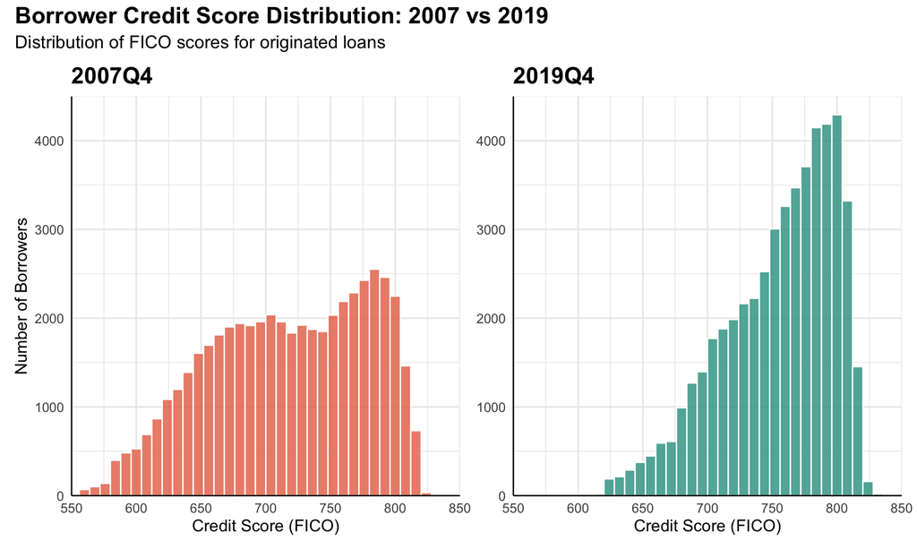

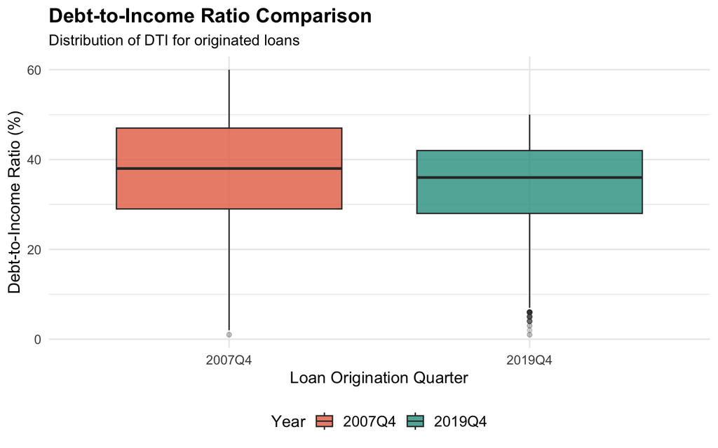

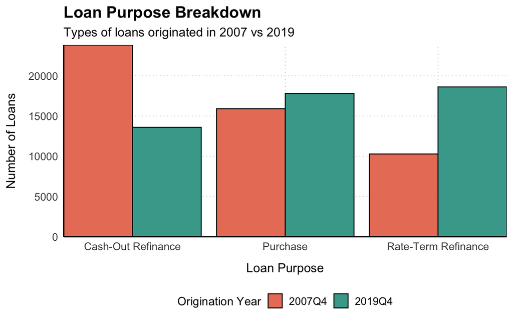

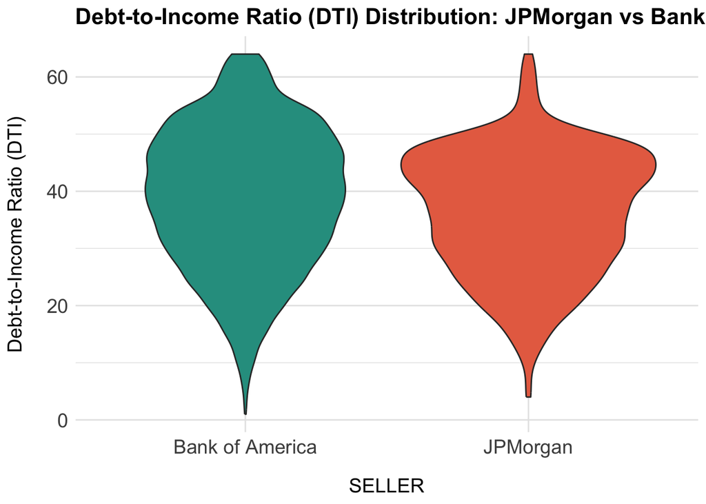

[figure not shown]

[interactive chart not shown]